# presentation_hms

Die Rolle subjektiver Parteibindung bei einstellungs- und verhaltensbezogener affektiver Polarisierung in 25 europäischen Demokratien

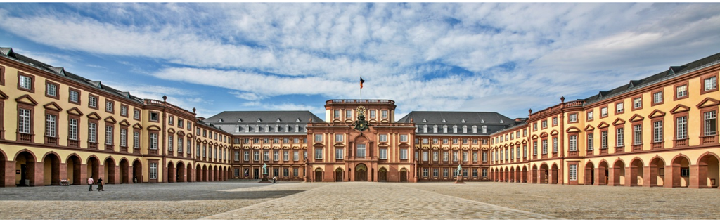

Tristan Muno

## Agenda

1. Polarisierung als Familie, nicht als Sache
2. Affektive Polarisierung
3. Empirische Einblicke
4. Fazit

# Polarisierung als Familie, nicht als Sache

## Ein gegenwärtiges Trendwort…

*Polarisierung*, *Polarisation*, *polarisieren*: Die Begriffsfamilie ist im – nicht nur deutschen – Sprachgebrauch allgegenwärtig

[figure not shown]

Merriam-Webster: Wort des Jahres 2024 (Merriam-Webster 2024)

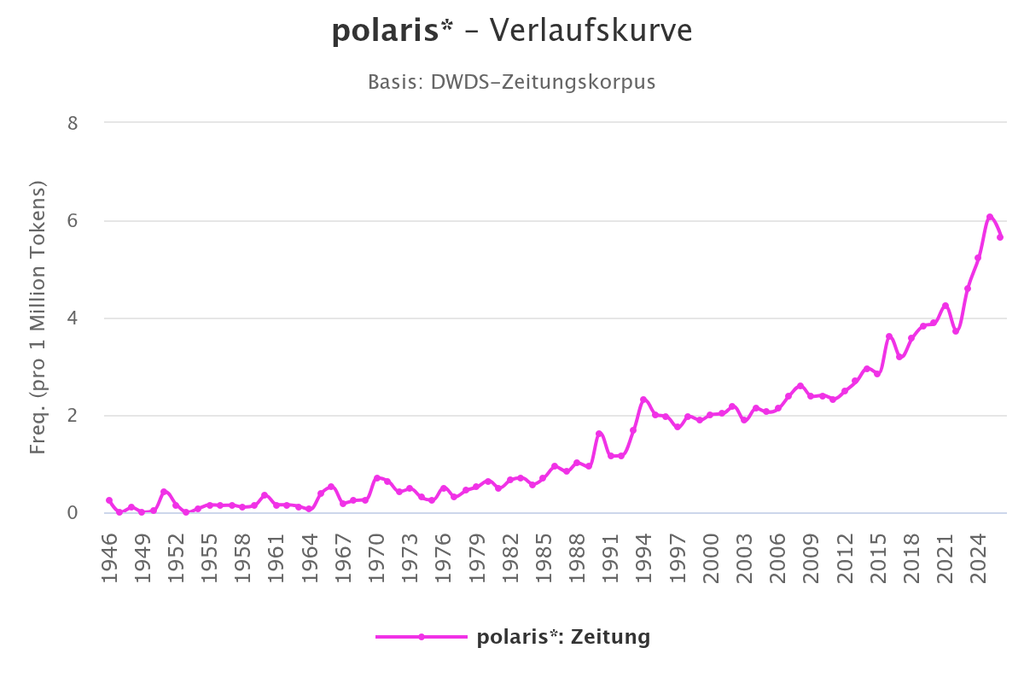

„polaris*“ im DWDS-Zeitungskorpus (Digitales Wörterbuch der deutschen Sprache 2026)

## … mit langer Geschichte …

- **Antike:** Griechisch *polos*, lateinisch *polus*: die Achse, um die sich etwas dreht (Online Etymology Dictionary 2026c)
  - Drehpunkt, Himmelsachse, geographische Pole
  - Das Adjektiv *polar* kommt erst später über das Mittellateinische (Online Etymology Dictionary 2026a)
- **19. Jh., Physik:** Polarisation als Orientierung/Ausrichtung (Online Etymology Dictionary 2026b)
  - Optik: Lichtwellen werden in einer Ebene ausgerichtet (Begriff und Verb Malus (1811))
  - Elektromagnetismus: Ladungen bzw. Pole werden gegensätzlich angeordnet
- **Ab 1945 vermehrt Soziologie/Psychologie:** Übertragung auf soziale und politische Gruppen als Bestehen bzw. Verstärkung von Unterschieden (Online Etymology Dictionary 2026b)
  - Hier kommen Spaltung und Konflikt als Wertung hinzu

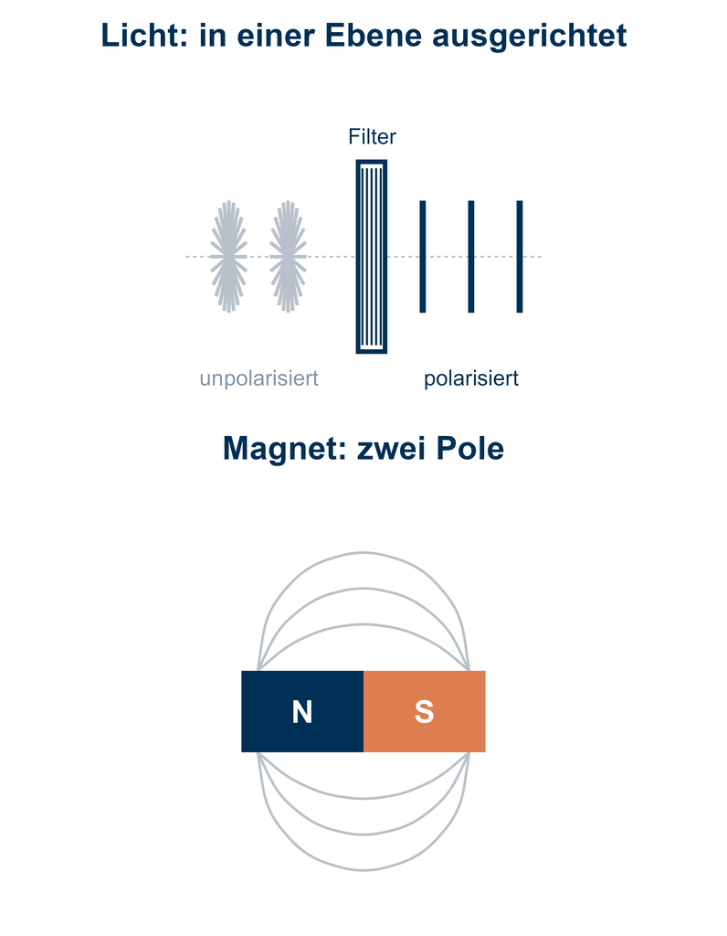

## … und mindestens vier Gesichtern …

- Mindestens vier mathematisch verschiedene Konzepte – die sich **in denselben Daten gegenläufig** verhalten können

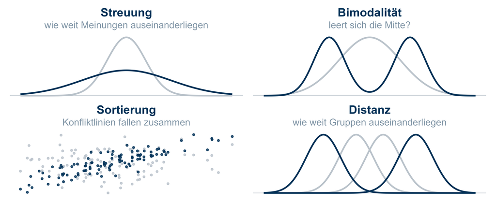

## … und drei offenen Fragen

- Zwei Lager (bipolar) oder viele (multipolar)?
- Zustand oder Dynamik/Prozess?
- Wer ist polarisiert (Population) – und gegen wen/was (Ziel)?

## Quer dazu: Wahrnehmung und Wirklichkeit

- Jedes dieser Konzepte gibt es **zweimal**: wie es ist – und wie es wahrgenommen wird
- Menschen überschätzen systematisch, wie extrem und wie anders „die anderen“ sind (Levendusky und Malhotra 2016; Ahler und Sood 2018)
- Wahrgenommene Polarisierung kann wachsen, während die tatsächliche gleich bleibt

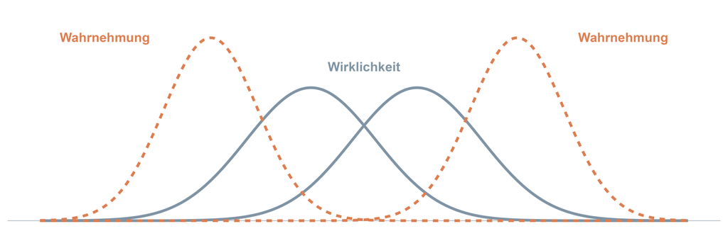

# Affektive Polarisierung

## Nicht *was* wir denken, sondern *wie wir fühlen*

- Statt Streit um ideologische Polarisierung (Fiorina u. a. 2008; Abramowitz und Saunders 2008): die „affektive Wende” – wie fühlen Anhänger *übereinander*? (Iyengar u. a. 2012)
- Kerngedanke: Parteianhängerschaft als **soziale Identität** – ein „Wir” und ein „Die anderen”
- Minimaldefinition: Sympathie für die **eigene** Seite, Ablehnung der **anderen**
- Die Abneigung kann weit über sachliche Meinungsunterschiede hinausgehen

## Auch hier: zwei Achsen, vier Zellen

Wem gilt die Abneigung – und wie wird sie gemessen? (vgl. Druckman und Levendusky 2019; Areal und Harteveld 2024)

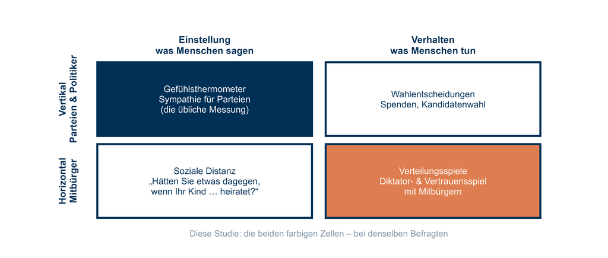

## Und was zählt als „eigene” Partei?

- Um affektive Polarisierung zu berechnen, braucht man eine „eigene” Partei – wer legt fest, welche das ist?
  - **Bindung:** die Partei, der man sich nahe fühlt
  - **Wahlentscheidung:** die Partei, die man gewählt hat
  - **Höchste Bewertung:** die Partei, die man am besten bewertet
- Schon vor jeder Schätzung stehen konzeptuelle Entscheidungen
- Und sie bestimmen die Grundgesamtheit, auf die sich die Schätzung bezieht (*population of inference*)

# Empirische Einblicke

## Engeres Verständnis: subjektive Parteibindung

- Aus Sicht der Theorie sozialer Identität zählt, wer sich einer Partei **zugehörig fühlt**
- Konsequenz: Wer *keine* Bindung angibt, fällt heraus

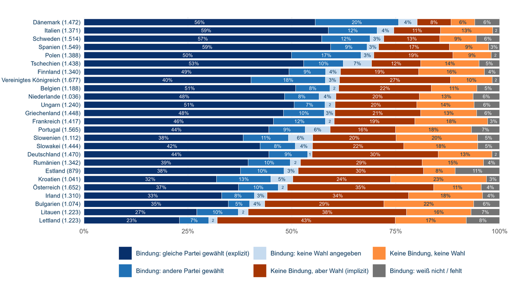

Daten: eu25games2019 (Muno und König 2026), basierend auf Hahm u. a. (2024), Wellen 2 und 3, nur Befragte mit bestandenem Aufmerksamkeitstest, ungewichtet. Insgesamt: 45% explizit, 11% Bindung: andere Partei gewählt, 3% Bindung: keine Wahl angegeben, 23% implizit, 14% Keine Bindung, keine Wahl, 5% Bindung: weiß nicht / fehlt.

## Der Vergleich: gleiche Partei, anderes Bekenntnis

- Vergleich zwischen expliziten und impliziten Anhängern **derselben Partei im selben Land**
- Für zwei Maße: vertikale Gefühlsthermometer und horizontale Verhaltensspiele
- Limitationen:
  - Ein Zeitausschnitt (d. h. lediglich Aussage über Polarisation als Zustand)
  - Messart (Einstellung/Verhalten) und Ziel (Partei/Person) nicht getrennt identifizierbar

## Messung: Einstellung und Verhalten

**Einstellung: Gefühlsthermometer**

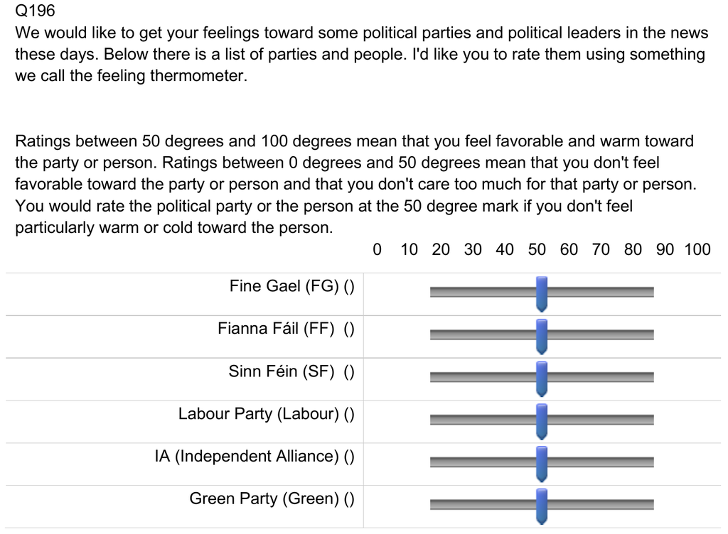

- 0–100 „Grad“ für jede **Partei** (vertikal), 50 neutral

**Verhalten: Diktator- und Vertrauensspiel**

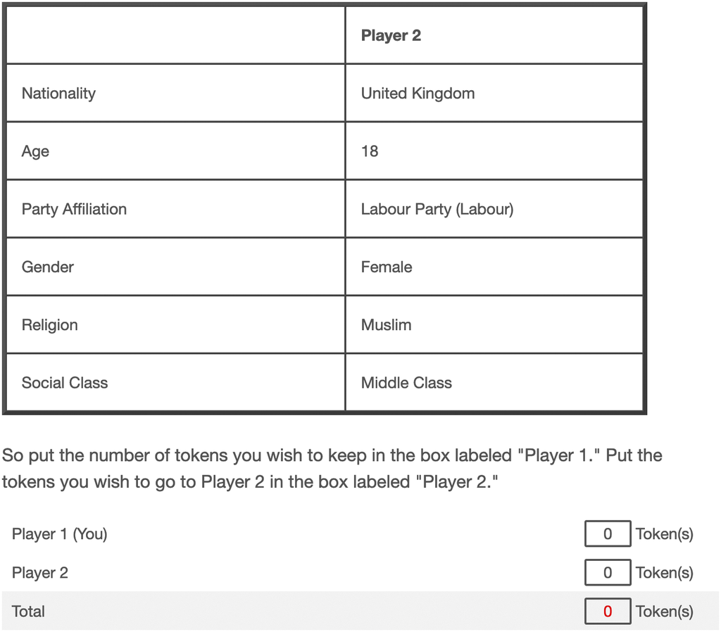

- 10 Punkte an eine **andere Person** (horizontal), Partei ist eines von sechs Merkmalen, je 3 Runden (Hahm u. a. 2024)

Für Messung $m \in \{\text{Thermometer}, \text{Spiele}\}$ und Typ $t \in \{\text{explizit}, \text{implizit}\}$, in SD-Einheiten von $Y^m$:

$$AP^m_t = E(Y^m \mid R = \text{eigen}, T = t) - E(Y^m \mid R = \text{fremd}, T = t), \qquad
\Delta AP^m = AP^m_{\text{explizit}} - AP^m_{\text{implizit}}$$

## Ergebnis: alle Länder zusammen

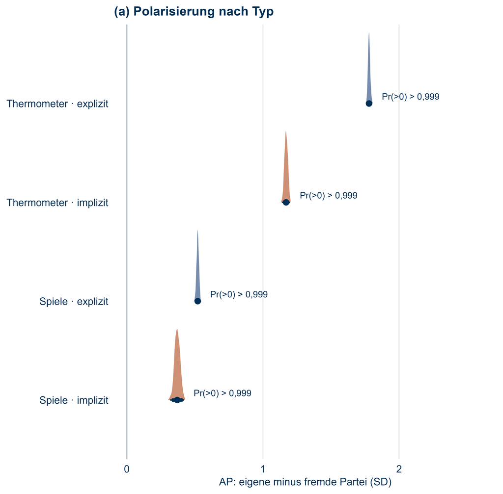

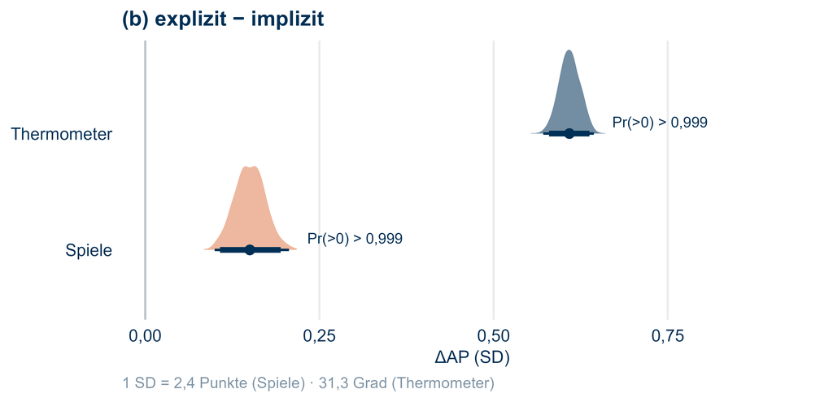

- Einstellungsbezogene AP ist systematisch **größer** als verhaltensbezogene
- In beiden Maßen sind **explizite** Anhänger stärker polarisiert als implizite
- **Aber:** Der Unterschied ist in den Verhaltensspielen deutlich **geringer**

## Was folgt daraus?

- **Messen heißt entscheiden:**
  - Wer wird mitgezählt? Anhänger, Wähler, Wahlberechtigte
  - Welche Facette deckt das Instrument ab? Vertikal oder horizontal, Einstellung oder Verhalten
  - Wird Polarisierung als Zustand oder Prozess verstanden?
- **Ergebnis:** Explizite Anhänger urteilen härter – handeln aber nur ein bisschen anders, robust über Länder hinweg (Anhang)
- **Parteiidentifikation** spielt für verhaltensbezogene AP eine wesentlich geringere Rolle
- **Horizontale AP** ist, am Verhalten gemessen, deutlich geringer als vertikale AP, gemessen an Einstellungen
- Da Letztere das etablierte Standardmaß vieler Studien ist: Nicht unwahrscheinlich, dass viele Schätzungen das Ausmaß affektiver Polarisierung in der Bevölkerung **überschätzen**

## Fazit

1. Es gibt nicht **die eine** Polarisierung
2. Es gibt eine messbare affektive Polarisierung in Europa zwischen eigener und anderen Parteien
3. Sinnvolle Aussagen über Ausmaß und Dynamik sind nur vor dem Hintergrund von Maß, Stichprobenzusammensetzung und den damit verbundenen konzeptionellen Entscheidungen möglich
4. Alarmistische Erzählungen helfen wenig – und stehen auf dünner empirischer Grundlage
5. Die einfache Gleichung „mehr Polarisierung = schlechter“ wird von neueren Studien differenziert:
   - Weniger Animosität ändert demokratische Einstellungen nicht (Broockman u. a. 2023)
   - Der Zusammenhang ist nicht linear, sondern eher umgekehrt U-förmig (Janssen und Turkenburg 2024)
   - Die Ablehnung radikaler Parteien kann eine Leitplanke sein (Harteveld u. a. 2022; Mason 2026)
   - Gegner oder Feind? (Westphal 2025; Mouffe 2013)

# Vielen Dank für Ihre Aufmerksamkeit!

Ich freue mich über Fragen, Kritik und Anregungen ❤

## Literatur

Abramowitz, Alan I., und Kyle L. Saunders. 2008. „Is Polarization a Myth?“ *The Journal of Politics* 70 (2): 542–55. https://doi.org/10.1017/S0022381608080493.

Ahler, Douglas J., und Gaurav Sood. 2018. „The Parties in Our Heads: Misperceptions about Party Composition and Their Consequences“. *The Journal of Politics* 80 (3): 964–81. https://doi.org/10.1086/697253.

Areal, João, und E. Harteveld. 2024. „Vertical vs horizontal affective polarization: Disentangling feelings towards elites and voters“. *Electoral Studies* 90. https://doi.org/10.1016/j.electstud.2024.102814.

Broockman, David E., Joshua L. Kalla, und Sean J. Westwood. 2023. „Does Affective Polarization Undermine Democratic Norms or Accountability? Maybe Not“. *American Journal of Political Science* 67 (3): 1–21. https://doi.org/10.1111/ajps.12719.

Bürkner, Paul-Christian. 2017. „brms: An R Package for Bayesian Multilevel Models Using Stan“. *Journal of Statistical Software* 80 (1): 1–28. https://doi.org/10.18637/jss.v080.i01.

Digitales Wörterbuch der deutschen Sprache. 2026. „DWDS-Verlaufskurve für ,,polaris““. DWDS-Zeitungskorpus. https://www.dwds.de/r/plot/?view=1&corpus=zeitungenxl&norm=date%2Bclass&smooth=spline&genres=0&grand=1&slice=1&prune=0&window=0&wbase=0&logavg=0&logscale=0&xrange=1946%3A2026&q1=polaris*.

Druckman, James, und Matthew Levendusky. 2019. „What Do We Measure When We Measure Affective Polarization?“ *Public Opinion Quarterly* 83 (1): 114–22. https://doi.org/10.1093/poq/nfz003.

Fiorina, Morris P., Samuel A. Abrams, und Jeremy C. Pope. 2008. „Polarization in the American Public: Misconceptions and Misreadings“. *The Journal of Politics* 70 (2): 556–60. https://doi.org/10.1017/S002238160808050X.

Hahm, Hyeonho, David Hilpert, und Thomas König. 2023. „Divided by Europe: affective polarisation in the context of European elections“. *West European Politics* 46 (4): 705–31. https://doi.org/10.1080/01402382.2022.2133277.

Hahm, Hyeonho, David Hilpert, und Thomas König. 2024. „Divided We Unite: The Nature of Partyism and the Role of Coalition Partnership in Europe“. *American Political Science Review* 118 (1): 69–87. https://doi.org/10.1017/S0003055423000266.

Harteveld, Eelco, Philipp Mendoza, und Matthijs Rooduijn. 2022. „Affective Polarization and the Populist Radical Right: Creating the Hating?“ *Government and Opposition* 57 (4): 703–27. https://doi.org/10.1017/gov.2021.31.

Iyengar, Shanto, Gaurav Sood, und Yphtach Lelkes. 2012. „Affect, Not Ideology: A Social Identity Perspective on Polarization“. *Public Opinion Quarterly* 76 (3): 405–31. https://doi.org/10.1093/poq/nfs038.

Janssen, Lisa, und Emma Turkenburg. 2024. „Breaking free from linear assumptions: Unravelling the relationship between affective polarization and democratic support“. *European Journal of Political Research* 64: 1465–2479. https://doi.org/10.1111/1475-6765.12725.

Levendusky, Matthew S., und Neil Malhotra. 2016. „(Mis)perceptions of Partisan Polarization in the American Public“. *Public Opinion Quarterly* 80 (S1): 378–91. https://doi.org/10.1093/poq/nfv045.

Malus, Étienne-Louis. 1811. „Mémoire sur de nouveaux phénomènes d’optique“. *Nouveau Bulletin des Sciences par la Société Philomathique de Paris* 2: 291–95. http://babel.hathitrust.org/cgi/pt?id=chi.44245869;view=1up;seq=299.

Mason, Lilliana. 2026. „Polarization Is Not the Problem“. *Journal of Democracy* 37 (4): 105–14. https://doi.org/10.1353/jod.2026.a1001900.

Merriam-Webster. 2024. „Word of the Year 2024“. https://www.merriam-webster.com/wordplay/word-of-the-year-2024.

Mouffe, Chantal. 2013. *Agonistics: Thinking the World Politically*. Verso Books.

Muno, Tristan, und Thomas König. 2026. *eu25games2019: A Cleaned Three-Wave EU Elections Survey (2019) across 25 Countries*. Version 1.0.0. Zenodo. https://doi.org/10.5281/zenodo.21294634.

Online Etymology Dictionary. 2026a. „Origin and History of Polar“. https://www.etymonline.com/word/polar.

Online Etymology Dictionary. 2026b. „Origin and History of Polarize“. https://www.etymonline.com/word/polarize.

Online Etymology Dictionary. 2026c. „Origin and History of Pole“. https://www.etymonline.com/word/Pole.

Westphal, Manon. 2025. „Affective polarization and political theory“. In *Handbook of Affective Polarization*, herausgegeben von Mariano Torcal und Eelco Harteveld. Edward Elgar Publishing. https://doi.org/10.4337/9781035310609.00008.

# Anhang

# Länderspezifische Ergebnisse

## Länder: AP Thermometer

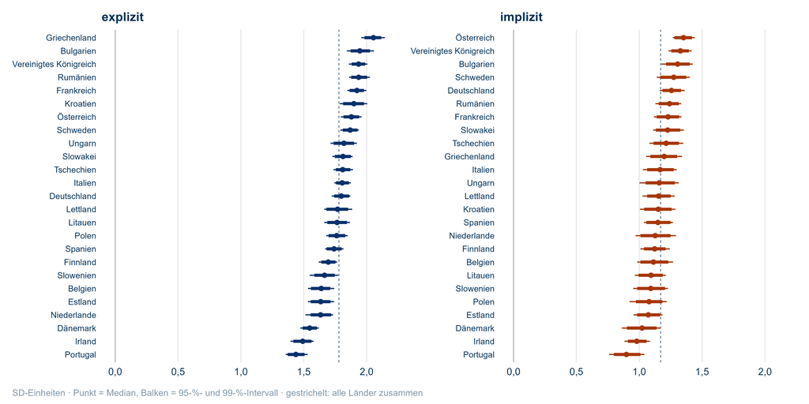

## Länder: AP Spiele

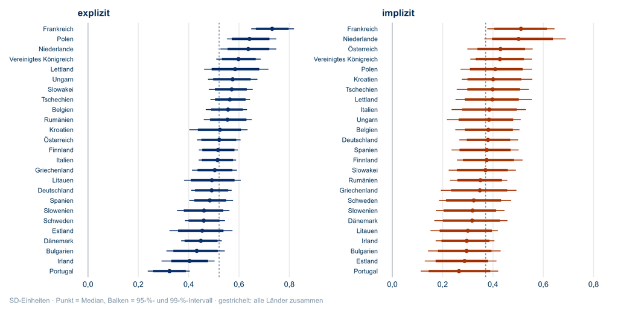

## Länder: ΔAP explizit − implizit

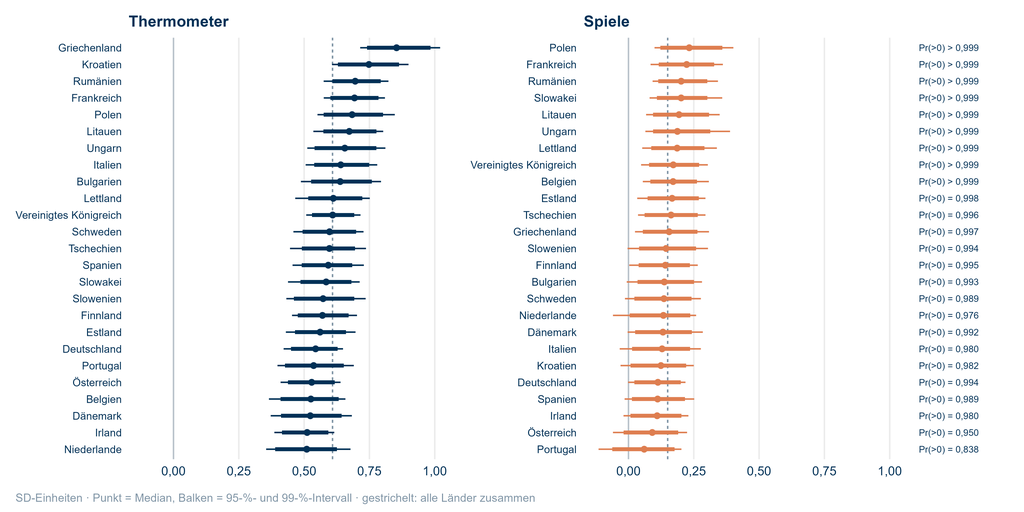

# Datengrundlage

## Frageformulierungen (eu25games, Irland)

**Parteibindung** (Wellen 2 und 3, Q52)

- *„Do you consider yourself to be close to any particular political party? If so, which party do you feel close to?“*
- Antwortoptionen: die Parteien des Landes, „Other“ – und *„No, I do not feel close to any political party“*

**Wahl** (Europawahl 2019)

- Welle 2: *„Which party did you give your 1st preference vote to in this election?“* / *„Which party will you give …?“* / hypothetisch: *„Just assuming you were going to vote …“*
- Welle 3: *„Which party did you give your 1st preference vote to in this election?“* / Nichtwähler: *„Just assuming you had voted in the election, which party would you have voted for?“*

**Explizit** = Bindung an eine Partei **und** Wahl derselben Partei. **Implizit** = „No, I do not feel close to any political party“ **und** eine Partei bei der Wahlfrage.

## Stichprobe

|  | Beobachtungen | Befragte | Länder |
| --- | --- | --- | --- |
| Spiele (Runden) | 66.505 | 20.385 | 25 |
| Thermometer (Bewertungen) | 123.972 | 20.662 | 25 |

- **Daten:** dreiwellige Befragung zur Europawahl 2019 in 25 Ländern, teils Panel, teils Auffrischungsstichprobe (Hahm u. a. 2023, 2024)
- **Bereinigte, harmonisierte Fassung** (Muno und König 2026) auf Zenodo: doi.org/10.5281/zenodo.21294634
- Spiele und Thermometer aus Wellen 2 und 3: je 6 Runden bzw. 6 bewertete Parteien pro Befragtem; Befragte, die den Aufmerksamkeitstest bestanden und den Fragebogen abgeschlossen haben
- **Analysestichprobe:** explizite und implizite Anhänger; in den Spielen nur Runden, in denen die Partei des Gegenübers gezeigt wurde, im Thermometer nur Bewertungen der eigenen und fremder Parteien

# Modellspezifikationen

## Linearer Prädiktor

Beobachtung $i$: eine Runde bzw. eine Bewertung von Person $j[i]$, deren Partei $p[i]$ in Land $c[i]$ liegt (Index-Lookup: $c[i]$ = „das Land von Beobachtung $i$“)

$$\eta_i = \alpha + \beta_R R_i + \beta_T T_i + \beta_{RT} R_i T_i + \boldsymbol{\gamma}^\top \mathbf{x}_i + \mathbf{z}_i^\top \left(\mathbf{u}_{c[i]} + \mathbf{u}_{c[i]p[i]}\right) + v_{j[i]}$$

- $R_i$: eigene (1) oder fremde (0) Partei; $T_i$: explizit (1) oder implizit (0)
- $\alpha$: Achsenabschnitt – implizite Anhänger gegenüber einer fremden Partei, Kontrollen auf Referenzkategorie
- $\beta_R$: Abstand eigen/fremd der Impliziten; $\beta_T$: Unterschied explizit/implizit gegenüber Fremden; $\beta_{RT}$: um wie viel der Abstand eigen/fremd bei Expliziten größer ist – die drei **fokalen Terme**
- $\boldsymbol{\gamma}^\top \mathbf{x}_i = \sum_k \gamma_k x_{ik}$: Kontrollen als Dummies – Spiel, Runde, Welle, gezeigte Profilmerkmale (Spiele) bzw. Welle (Thermometer)
- $\mathbf{z}_i = (1, R_i, T_i, R_i T_i)^\top$ wiederholt das fokale Design: $\mathbf{u}_c$ enthält die Abweichungen von Land $c$ von $\alpha, \beta_R, \beta_T, \beta_{RT}$; $\mathbf{u}_{cp}$ die Abweichungen der Partei $p$ von ihrem Land – der Vergleich wird so **innerhalb jeder Partei** geschätzt
- $v_j$: Personeneffekt über Runden, Bewertungen und Wellen hinweg

## Verteilung der Ergebnisvariablen

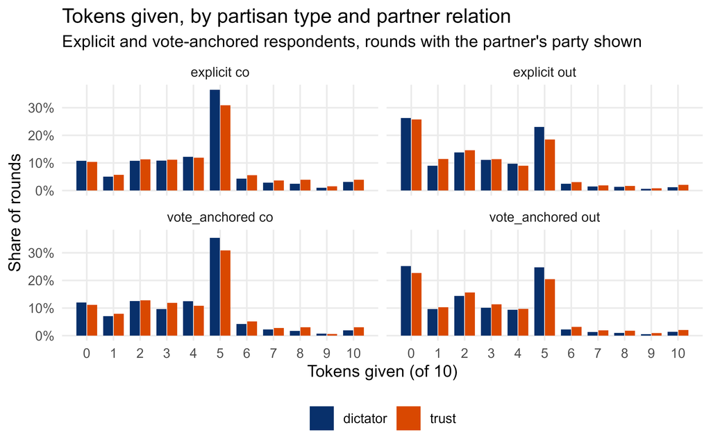

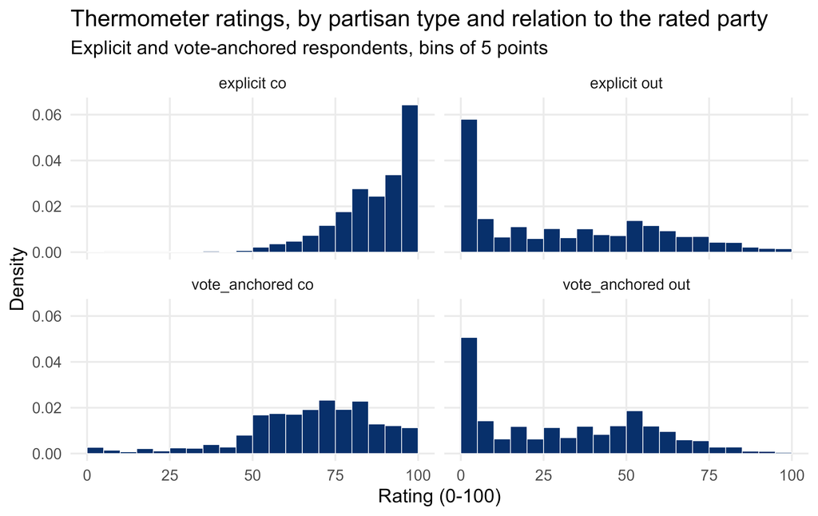

- **Nicht normalverteilt:** Häufungen bei 0 und 5 Punkten (Spiele) bzw. bei 0 und 100 Grad (Thermometer)
- **Trotzdem ein lineares Modell:** AP und ΔAP sind Kontraste **bedingter Erwartungswerte** (Zellmittel); ein Gauß-Modell mit Identitäts-Link bildet diese auch bei falscher Verteilungsform ab
- **Robustheit:** zusätzlich ein Beta-Binomial-Modell geschätzt – die Ergebnisse bleiben gleich (letzte Folie)

## Gauß-Modell

**Priors** – alle Koeffizienten **um null zentriert**

$$\begin{aligned}
\alpha &\sim \text{Normal}(0,\, 0{,}5) \\
\beta_R,\ \beta_T,\ \beta_{RT} &\sim \text{Normal}(0,\, 1) \\
\gamma_k &\sim \text{Normal}(0,\, 0{,}2) \\
\mathbf{u}_c \sim \text{MVN}(\mathbf{0}, \Sigma_C), &\quad \mathbf{u}_{cp} \sim \text{MVN}(\mathbf{0}, \Sigma_P) \\
\Sigma &= \text{diag}(\boldsymbol{\tau})\, \Omega\, \text{diag}(\boldsymbol{\tau}) \\
v_j &\sim \text{Normal}(0,\, \sigma_v) \\
\tau_k,\ \sigma_v &\sim \text{Exponential}(5) \\
\Omega_C,\ \Omega_P &\sim \text{LKJ}(2) \\
\sigma &\sim \text{Exponential}(2)
\end{aligned}$$

**Likelihood** – $Y^z$ z-standardisiert

$$Y^z_i \sim \text{Normal}(\eta_i,\, \sigma), \qquad
p(\mathbf{Y} \mid \boldsymbol{\theta}, \mathbf{X}) = \prod_i \text{Normal}(Y^z_i \mid \eta_i,\, \sigma)$$

**Posterior**

$$p(\boldsymbol{\theta} \mid \mathbf{Y}, \mathbf{X}) \propto p(\mathbf{Y} \mid \boldsymbol{\theta}, \mathbf{X})\; p(\boldsymbol{\theta})$$

$$\boldsymbol{\theta} = (\alpha, \beta_R, \beta_T, \beta_{RT}, \boldsymbol{\gamma}, \mathbf{u}, \mathbf{v}, \boldsymbol{\tau}, \Omega, \sigma_v, \sigma)$$

**Von der Posterior zur Schätzgröße** – für jede Ziehung $s$: Typ und eigen/fremd für **alle beobachteten Zeilen** kontrafaktisch setzen, vorhersagen und mitteln (jede Person zählt gleich; nur Parteien mit expliziten **und** impliziten Anhängern)

$$AP_t^{(s)} = \sum_i w_i \left[\eta_i^{(s)}(R{=}1, T{=}t) - \eta_i^{(s)}(R{=}0, T{=}t)\right], \qquad
\Delta AP^{(s)} = AP_{\text{explizit}}^{(s)} - AP_{\text{implizit}}^{(s)}$$

Geschätzt mit brms (Bürkner 2017) (Stan, cmdstanr): 4 Ketten à 2.000 Iterationen (1.000 Warm-up), `adapt_delta` = 0,95; daraus 1.000 Ziehungen für die Schätzgrößen – deren Verteilung ergibt Median, Intervalle und Pr(>0).

## Robustheit: Beta-Binomial-Modell

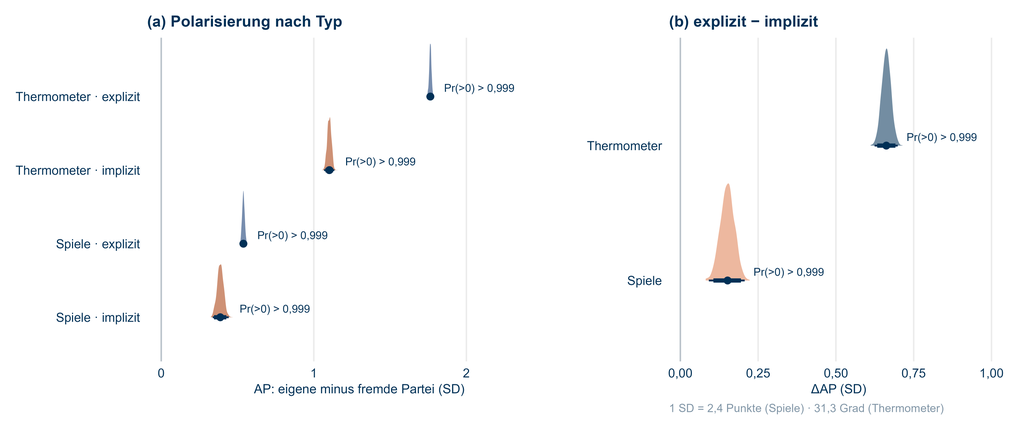

Beide Modellfamilien kommen zum selben Schluss: ΔAP Thermometer 19,1 (Gauß) bzw. 20,7 Grad (BB), Spiele 0,37 bzw. 0,37 Punkte, Unterschied der Unterschiede 0,46 bzw. 0,51 SD – jeweils mit Pr(>0) > 0,999.